# Session I: R Introduction

armandorp@ucm.es

2021-10-08

## Getting started in R

### 1. Using R as a calculator (arithmetic operators)

The simplest thing you can do with R is arithmetic operations, similar to Python:

```r
1 + 100
```

```
## [1] 101
```

You can use any other arithmetic operation such as:

- Add (sum)
- Subtract
- Multiply
- Divide
- Exponents
- Brackets / parentheses

Evaluate these operations:

```r
2 * 3 + 5
2 * (3 + 5)
```

See `help(Arithmetic)` or `?Arithmetic` to check the main arithmetic operations

### 2. Assignment of variables

```r
a <- 1 + 2
a = 1 + 2 # "<-" and "=" are the same thing
b = 2 + 1
```

Notice that assignment does not print any value, but you can always print them using `print(a)`

### 3. Other useful and common numeric commands/functions

```r
# Get the absolute value
abs(-2)
# Square root of any value
sqrt(4)
# natural logarithm
x <- 4
log(x)
# Common logarithm
log10(x); log(x = x, base = 10 ) # you can use ; to separte line of code
# Antilog
10^log(x, 10)
# Round a number with 2 decimals
round(3.475, digits=2)
# Round a number with 1 decimals
round(3.475, digits=1)
```

### 4. Comparisons

```r
1 + 2 == 2 + 1

a = 1 + 2
b = 2 + 1

# a == b is the same but using variables instead
a == b

# you can also ask whether they are different
a != b
```

Check when object less or greater than:

```r
a < b

# What does "b" represent after running this?
b <- b + 1

a < b
```

See `help(Comparison)` or `?Comparison` to check the main arithmetic operations

### 5. The Workspace in R

The workspace is your current R working environment and includes any user-defined objects (vectors, matrices, data frames, lists, functions). At the end of an R session, the user can save an image of the current workspace which is automatically reloaded the next time that R is initialized. Commands are entered interactively at the R user prompt. Up and down arrow keys scroll through your command history.

The “ls”’’ function shows all the objects in your workspace:

```r
ls()
```

#### 5.1. The “current” working directory

The working directory is the local folder at your PC that will be used for reading or saving any file in R by default.

To check which is our Current Working Directory (CWD) use:

```r
getwd()
```

You can always change your working directory:

```r
setwd("/Users/mydirectory")  # change to mydirectory
```

#### 5.2. Save your workspace and continue later

You can save your workspace in the file **.RData** in the cwd using:

```r
mio <- c("a","b","c")
save.image()
```

Alternatively, you can save specific objects to a file, if you don’t specify the path, the cwd is assumed

```r
save(mio, file="my_R_objects.RData")
```

If you want to continue you can load a workspace into the current session and **again** if you don’t specify the path, the cwd is assumed

```r
load("my_R_objects.RData")
```

#### 5.3. History of used commands

You can easily recover several R commands that were used previously:

```r
history()
```

#### 5.4. Leaving R

**Note:** You will be prompted to save the workspace.

```r
q()
```

### 6. Basic type of data structure

Understanding data structure is **very important** because you will use them on a day-to-day basis in R programing and routines, and it uses to be one of the most common source of frustration among beginners. Consider that everything in R will be an R-object and some of them would be very basic (i.e. vectors) but others quite complexes.

There are 4 basic atomic classes:

1. logical (e.g., TRUE, FALSE)
2. integer (e.g., 2L) **Note:** Using “L” suffix, you get an integer rather than a numeric
3. numeric (real or decimal) (e.g, 2, 2.0, pi)
4. character (e.g, “a”, “swc”, “the book”), can be also called string

In R there are 5 main data structures that will review each of those data structure to understand their uses and other more complex objects:

1. **Vector**
2. **Matrix**
3. **Data frame**
4. **List** (It’s a vector where any element is of any kind)
5. **Array** (we will avoid them, but they have several uses)
6. Others are complex objects (i.e. SummarizedExperiment):

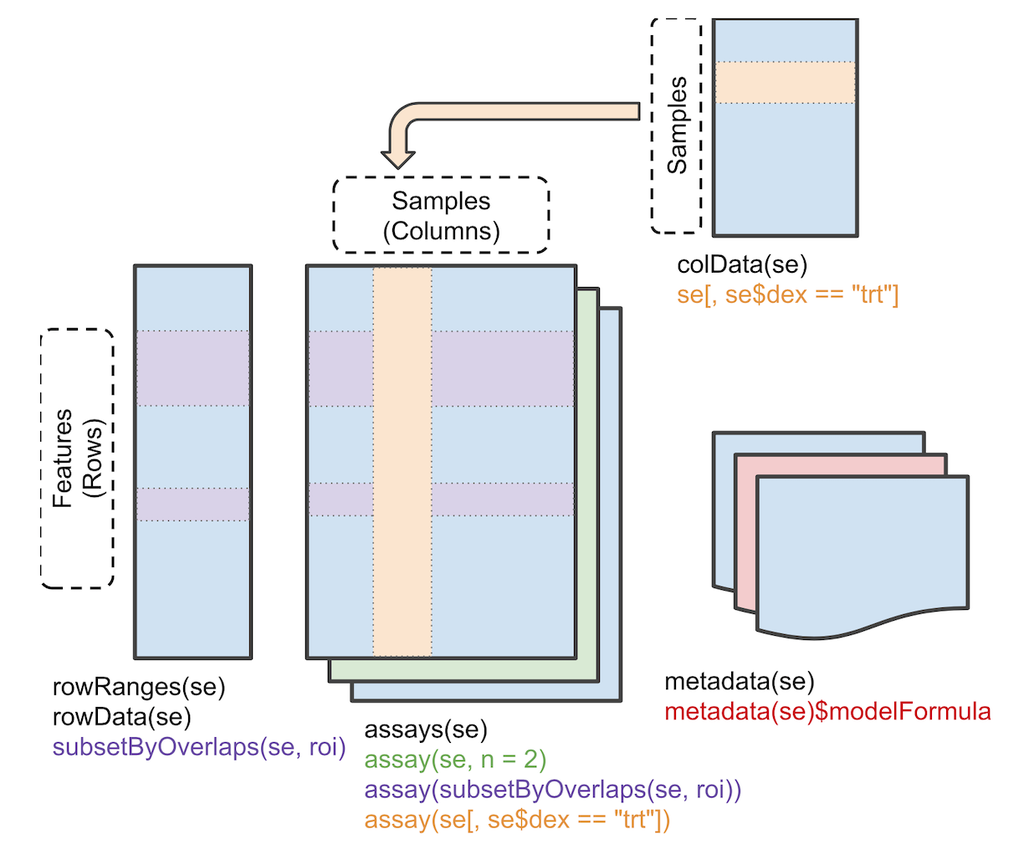